# 624 Week 1

### Data 5 Barrels from us_gasoline

Questions:

1. Can you spot any seasonality, cyclicity and trend?

   Ans: The line plot shows an upward trend for the gasoline production through the years. gg_season also confirms the upward trend for placing the later years higher in the graph and gg_subseries shows similar pattern as the autoplot line plot. ACF plot also shows that there is a general positive correlation between gasoline production and years (in weeks).
3. What can you say about the seasonal patterns?

   Ans: There isn’t a distinct seasonal pattern.
4. Can you identify any unusual years?

   Ans: There is a relatively big drop in gasoline production after 2009 week 53. However, the gasoline production picked up soon after.

```
## Plot variable not specified, automatically selected `.vars = Barrels`
```

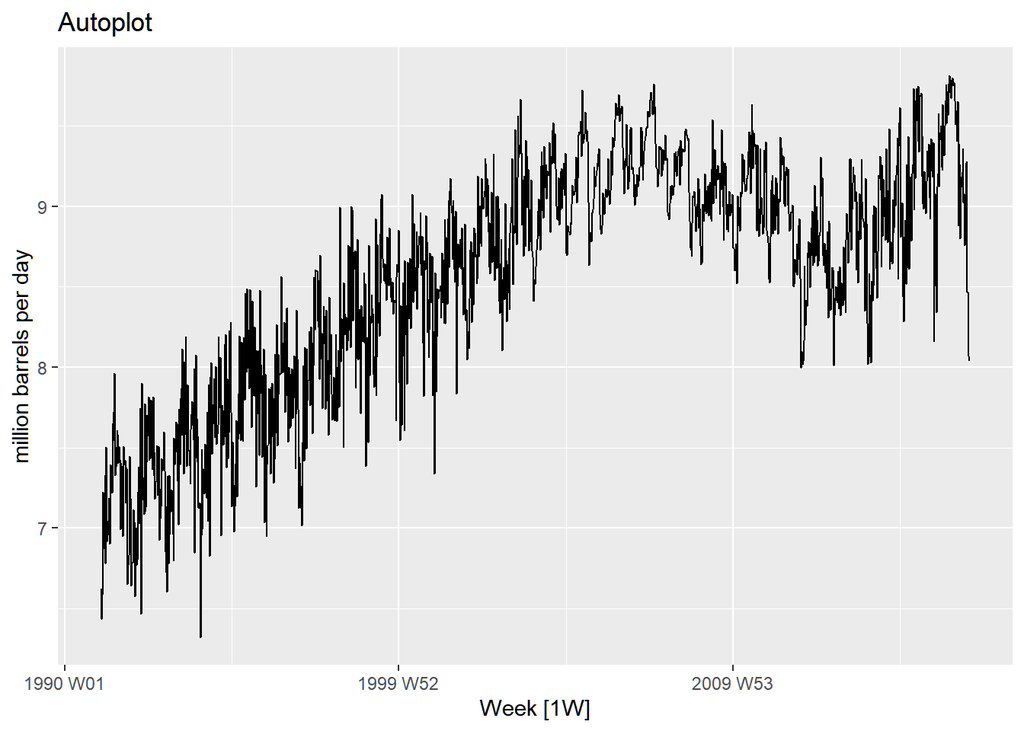

```r
autoplot(us_gasoline) + labs(y='million barrels per day', title = 'Autoplot')
```

```r
gg_season(us_gasoline) + labs(y='million barrels per day', title = 'gg_season')
```

```
## Plot variable not specified, automatically selected `y = Barrels`
```

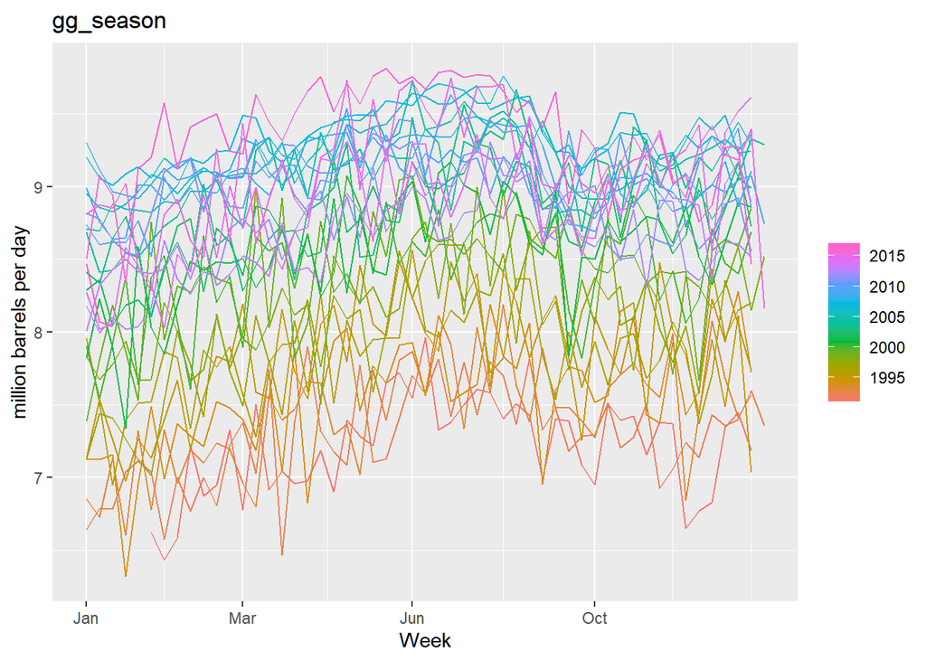